# 🛍️ Sales Trends Analysis for an E-Commerce Platform (Northwind DB)

Namshima Iordye

2025-07-02

## 1 Introduction: Unveiling Sales Insights from the Northwind Database

This project embarks on an exploratory data analysis journey into a simulated sales dataset, meticulously extracted from the well-known **Northwind database**. The Northwind database is a classic sample database often used for learning and demonstrating relational database concepts. By focusing on key sales transactions, this analysis aims to uncover valuable insights into product performance, customer ordering patterns, and temporal sales trends.

Our investigation is built upon a carefully curated set of columns directly extracted from the Northwind database using PostgreSQL:

- **`order_date`**: The specific date when an order was placed. This temporal dimension is crucial for understanding sales evolution over time.
- **`year`**: The year of the order, derived from `order_date`, allowing for annual trend analysis.
- **`month`**: The month of the order, derived from `order_date`, facilitating monthly performance evaluation and seasonality detection.
- **`product_name`**: The name of the individual product purchased, enabling analysis of popular items.
- **`category_name`**: The broader category to which each product belongs (e.g., “Beverages”, “Confections”), providing a higher-level view of sales distribution.
- **`unit_price`**: The price of a single unit of the product at the time of order, essential for calculating total sales value.
- **`order_quantity`**: The number of units of a specific product ordered in a single transaction, vital for understanding purchase volumes.

```
##   order_date year     month                    product_name  category_name
## 1 1996-07-04 1996 July                       Queso Cabrales Dairy Products
## 2 1996-07-04 1996 July        Singaporean Hokkien Fried Mee Grains/Cereals
## 3 1996-07-04 1996 July               Mozzarella di Giovanni Dairy Products
## 4 1996-07-05 1996 July                                 Tofu        Produce
## 5 1996-07-05 1996 July                Manjimup Dried Apples        Produce
## 6 1996-07-08 1996 July      Jack's New England Clam Chowder        Seafood
##   unit_price order_quantity
## 1       14.0             12
## 2        9.8             10
## 3       34.8              5
## 4       18.6              9
## 5       42.4             40
## 6        7.7             10
```

## 2 🔍 Goals

Through the systematic examination of these variables, we intend to:

- Identify top-selling products and product categories.
- Analyze sales performance across different years and months.
- Explore relationships between product pricing, quantity ordered, and overall sales.
- Calculate average order value over time
- Potentially uncover seasonal trends or anomalies in purchasing behavior.

Ultimately, the goal of this project is to transform raw sales data into actionable business intelligence, providing a foundational understanding of the Northwind company’s sales dynamics.

## 3 🛠️ Tools & Technologies

- **PostgreSQL** – SQL querying of relational data
- **R** – Data cleaning, wrangling, visualization
- **ggplot2** – Visualization of sales trends
- **DBI + RPostgres** – PostgreSQL connection from R

## 4 Unveiling Northwind’s Revenue Drivers: A Deep Dive into Top-Performing Products and Categories

**The Challenge:** Understanding the core of any successful sales operation begins with identifying its primary revenue generators. For Northwind Traders, a clear picture of which products and categories contribute most significantly to the bottom line is essential for strategic decision making, inventory management, marketing focus, and overall business growth.

**Our Approach:** To address this fundamental question, we initiated an exploratory data analysis, leveraging the detailed sales transaction data from the Northwind database. Our methodology involved:

1. **Aggregating Sales by Category:** We first calculated the `total_revenue` for each `category_name` by summing `unit_price * order_quantity` across all transactions.
2. **Identifying Top Categories:** The aggregated category data was then sorted in descending order of `total_revenue` to highlight the most lucrative categories.
3. **Visualizing Category Performance:** A bar chart was generated to provide a clear, at a glance comparison of total revenue across all product categories.
4. **Aggregating Sales by Product:** Following the category analysis, we performed a similar aggregation to calculate `total_revenue` for each individual `product_name`.
5. **Identifying Top Products:** The product data was then sorted by `total_revenue`, and the top 20 products were specifically extracted for detailed examination.
6. **Visualizing Product Performance:** Another bar chart was created to visually represent the revenue contribution of the top 20 products, allowing for easy comparison.

**Key Findings & Insights:**

### 4.1 Category Performance: The Dominant Segments

Our analysis of total revenue by category revealed a clear hierarchy of revenue contribution. The table below presents the total revenue generated by each product category, ordered from highest to lowest.

- **Strategic Implication:** The strong performance of Beverages, Dairy, and Meat/Poultry suggests these categories are foundational to Northwind’s revenue stream. Any strategies related to pricing, promotions, or new product introductions within these areas should be carefully considered for their potential significant impact on overall sales. Conversely, categories like Condiments, Produce, and Grains/Cereals, while contributing, represent smaller portions of the total revenue and might warrant different strategic approaches, perhaps focusing on niche marketing or operational efficiency.

### 4.2 Product Performance: The Individual Stars

Delving deeper into individual products, our analysis of the top 20 revenue-generating products offers granular insights into the specific items driving Northwind’s sales. The table below showcases these top products, along with their respective categories and total revenue.

- **Strategic Implication:** The identification of top-performing individual products like Côte de Blaye is critical. These items might be “cash cows” that deserve consistent stock levels, focused marketing efforts, and perhaps even premium placement. Understanding *why* these specific products perform so well (e.g., quality, price point, consistent demand) can inform strategies for other products within their categories or across the portfolio. Furthermore, by observing which categories these top products fall into, we reinforce the category-level insights – for example, a top-performing product from the Beverages category would further solidify Beverages as a critical segment.

**Conclusion & Next Steps:**

This initial analysis provides a vital snapshot of Northwind’s revenue landscape. We’ve successfully identified the most lucrative product categories and pinpointed the individual products that are the biggest contributors to total revenue.

These findings serve as a powerful foundation for further analysis. Future investigations could build upon this by:

- **Analyzing Profitability:** Moving beyond just revenue to understand the profit margins of these top categories and products.
- **Temporal Trends:** Examining how these top categories and products perform over different periods (e.g., monthly, quarterly) to identify seasonality or growth trends.
- **Customer Segmentation:** Linking these top sellers to specific customer segments to understand who is buying what.

By understanding what drives Northwind’s sales today, we empower informed decisions for sustainable growth and optimized operations moving forward.

### 4.3 Top 20 Performing Products By Revenue

| product_name | category_name | total_revenue |
| --- | --- | --- |
| Côte de Blaye | Beverages | 149984.2 |
| Thüringer Rostbratwurst | Meat/Poultry | 87736.4 |
| Raclette Courdavault | Dairy Products | 76296.0 |
| Camembert Pierrot | Dairy Products | 50286.0 |
| Tarte au sucre | Confections | 49827.9 |
| Gnocchi di nonna Alice | Grains/Cereals | 45121.2 |
| Manjimup Dried Apples | Produce | 44742.6 |
| Alice Mutton | Meat/Poultry | 35482.2 |
| Carnarvon Tigers | Seafood | 31987.5 |
| Rössle Sauerkraut | Produce | 26865.6 |
| Mozzarella di Giovanni | Dairy Products | 25738.8 |
| Ipoh Coffee | Beverages | 25079.2 |
| Gudbrandsdalsost | Dairy Products | 24307.2 |
| Sir Rodney’s Marmalade | Confections | 23635.8 |
| Wimmers gute Semmelknödel | Grains/Cereals | 23009.0 |
| Uncle Bob’s Organic Dried Pears | Produce | 22464.0 |
| Ikura | Seafood | 22140.2 |
| Gumbär Gummibärchen | Confections | 21534.9 |
| Perth Pasties | Meat/Poultry | 21510.2 |
| Flotemysost | Dairy Products | 20876.5 |

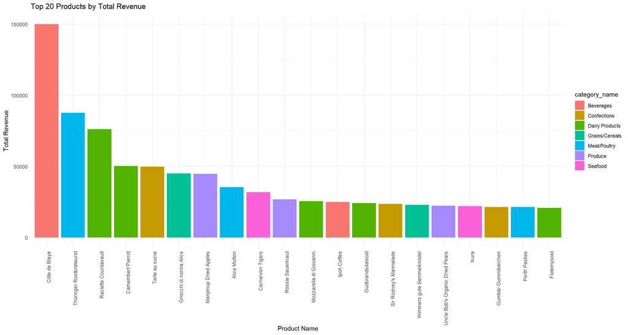

### 4.4 Top Performing Categories By Revenue

| category_name | total_revenue |
| --- | --- |
| Beverages | 286527.0 |
| Dairy Products | 251330.5 |
| Meat/Poultry | 178188.8 |
| Confections | 177099.1 |
| Seafood | 141623.1 |
| Condiments | 113694.8 |
| Produce | 105268.6 |
| Grains/Cereals | 100726.8 |

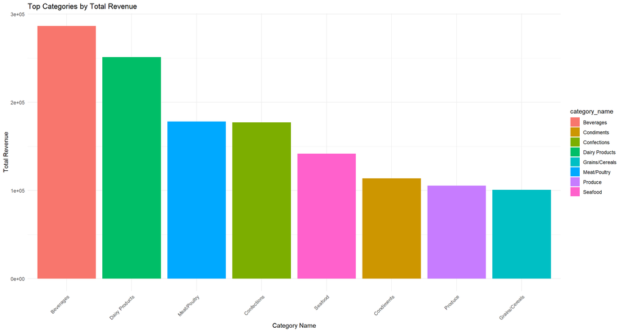

## 5 Tracking Northwind’s Pulse: Uncovering Seasonal Trends and Annual Performance Dynamics

**The Challenge:** While identifying top-performing products and categories provides a static snapshot of success, a deeper understanding of sales performance requires a temporal lens. Businesses thrive on predictability and the ability to adapt to fluctuating demand. For Northwind, discerning seasonal trends and year-over-year shifts in sales is vital for optimizing inventory, planning marketing campaigns, managing staffing and forecasting future revenue.

**Our Approach:** To uncover these temporal dynamics, our exploratory data analysis extended to examining sales patterns across different time dimensions. Specifically, we focused on:

1. **Overall Annual Revenue:** Calculating the total revenue for each year to observe general growth or decline.
2. **Monthly Revenue Trends:** Aggregating total revenue by month (across all years combined) to identify consistent seasonal peaks and troughs.
3. **Year-Month Revenue Breakdown:** Analyzing total revenue by the combination of year and month to pinpoint specific periods of high or low performance and track monthly evolution within each year.
4. **Annual Performance of Top Products:** Identifying the top-performing products within each year to see if the leading products remain consistent or shift over time.
5. **Annual Performance of Top Categories:** Similarly, examining the top-performing categories year-by-year to assess the stability or evolution of category dominance.

**Key Findings & Insights:**

### 5.1 Overall Sales Performance: A Journey Through Time

Our high-level analysis of annual revenue provides the overarching context for Northwind’s sales trajectory.

- **Strategic Implication:** The strong performance in 1997 warrants further investigation to understand what factors contributed to its success. Conversely, the apparent dip in 1998 (though it is likely an incomplete year’s data) highlights the importance of analyzing complete annual cycles for accurate growth assessment.

### 5.2 Monthly Revenue Dynamics: Unveiling Seasonal Rhythms

Delving into monthly sales, we identified distinct patterns that indicate seasonality in Northwind’s operations.

When we break down the monthly revenue performance across individual years, a clearer picture of these seasonal rhythms emerges:

### 5.3 Evolving Performance: Top Products and Categories Year-over-Year

To understand if Northwind’s core revenue drivers remain constant, we examined the performance of products and categories on an annual basis.

**Top Categories Per Year:**

- **Strategic Implication:** Observing these shifts is crucial. It helps confirm the consistent importance of major categories but also alerts us to any emerging or declining trends within them. This allows for adaptive strategies, such as reallocating marketing spend or exploring new product lines within categories showing increasing momentum.

**Top Products Per Year:**

Similar to categories, while some products like **Côte de Blaye** maintain a strong presence, the specific list of top 5 or top 10 products can vary annually. For example, Côte de Blaye was a top performer across 1996 and 1997.

- **Strategic Implication:** The consistency of top performers like Côte de Blaye reinforces their status as “cash cows” requiring stable management. However, the appearance of new products in the top ranks or the disappearance of others can signal market shifts, changing customer preferences, or the success/failure of specific product initiatives. This annual product review supports agile product portfolio management.

**Conclusion & Next Steps:**

This temporal analysis has provided crucial insights into Northwind’s sales dynamics, revealing significant seasonal patterns and confirming the consistent, yet evolving, dominance of certain product categories and individual items. The insights derived from annual and monthly trends empower Northwind to move beyond reactive operations towards proactive planning.

Future analysis should delve deeper into:

- **Seasonality Drivers:** Investigating external factors (holidays, events) that might influence the observed seasonal peaks.
- **1998 Data Completion:** Obtaining the full 1998 dataset to accurately assess annual growth/decline.
- **Product Lifecycle:** Tracking individual product performance over multiple years to understand their lifecycle (growth, maturity, decline).
- **Promotional Effectiveness:** If promotional data were available, correlating marketing activities with sales spikes.

By integrating these temporal insights into strategic planning, Northwind can optimize its operations, enhance customer satisfaction, and drive sustained revenue growth.

### 5.4 Seasonal Trend by Months

| month | total_revenue |
| --- | --- |
| April | 190329.95 |
| January | 167547.52 |
| March | 149805.35 |
| February | 145769.15 |
| December | 128429.66 |
| October | 111532.10 |
| November | 95617.36 |
| September | 87369.02 |
| July | 85657.03 |
| May | 76722.36 |
| August | 76591.09 |
| June | 39088.00 |

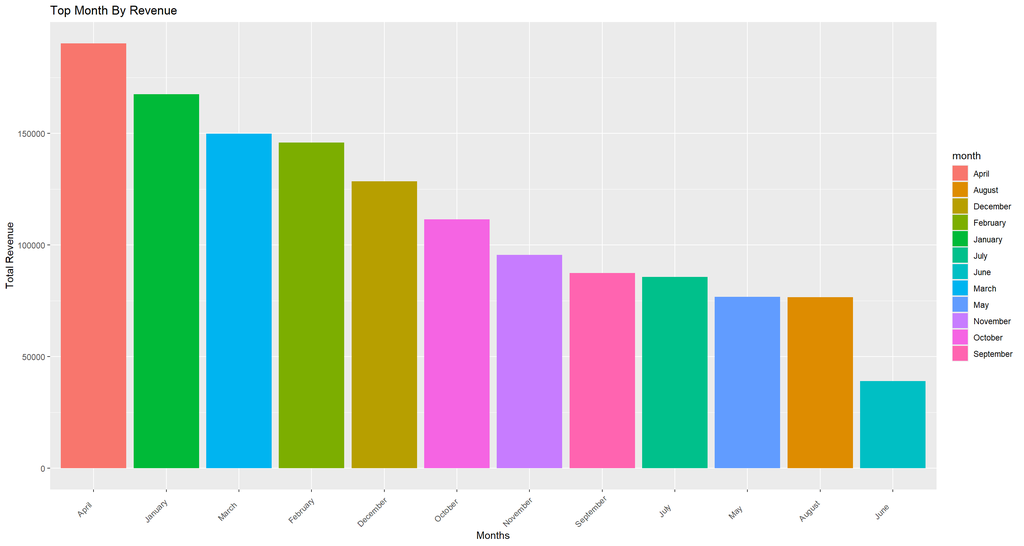

### 5.5 Seasonal Trend By year

| year | total_revenue |
| --- | --- |
| 1997 | 658388.8 |
| 1998 | 469771.3 |
| 1996 | 226298.5 |

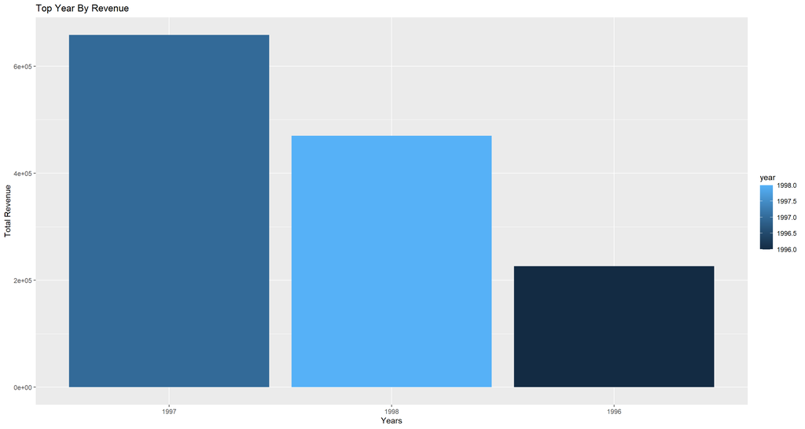

### 5.6 Seasonal Trend By Month Per Year

| year | month | total_revenue |
| --- | --- | --- |
| 1996 | December | 50953.40 |
| 1996 | November | 49704.00 |
| 1996 | October | 41203.60 |
| 1996 | July | 30192.10 |
| 1996 | September | 27636.00 |
| 1996 | August | 26609.40 |
| 1997 | December | 77476.26 |
| 1997 | October | 70328.50 |
| 1997 | January | 66692.80 |
| 1997 | September | 59733.02 |
| 1997 | May | 56823.70 |
| 1997 | April | 55699.39 |
| 1997 | July | 55464.93 |
| 1997 | August | 49981.69 |
| 1997 | November | 45913.36 |
| 1997 | February | 41207.20 |
| 1997 | March | 39979.90 |
| 1997 | June | 39088.00 |
| 1998 | April | 134630.56 |
| 1998 | March | 109825.45 |
| 1998 | February | 104561.95 |
| 1998 | January | 100854.72 |
| 1998 | May | 19898.66 |

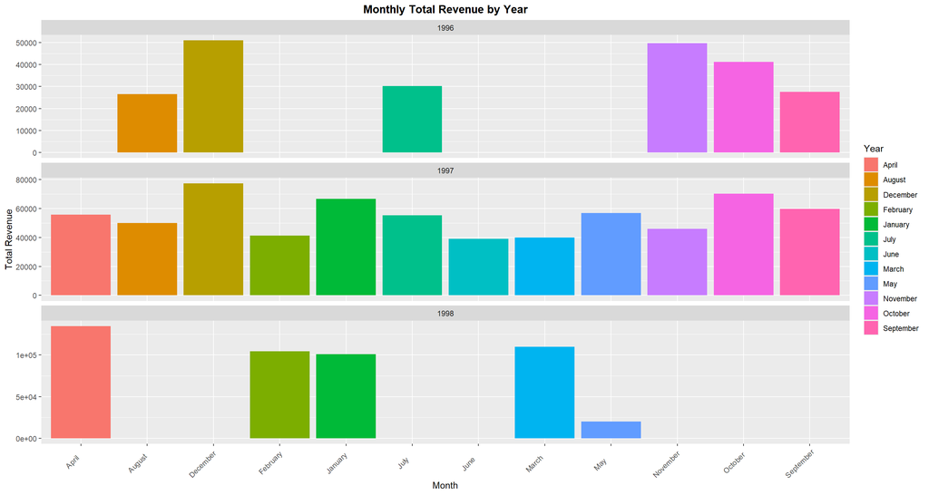

### 5.7 Seasonal Trend By Category Per Year

| year | category_name | total_revenue |
| --- | --- | --- |
| 1996 | Beverages | 53879.20 |
| 1996 | Dairy Products | 44615.80 |
| 1996 | Confections | 31511.60 |
| 1996 | Meat/Poultry | 30292.20 |
| 1996 | Seafood | 21589.60 |
| 1996 | Condiments | 19458.30 |
| 1996 | Produce | 15134.20 |
| 1996 | Grains/Cereals | 9817.60 |
| 1997 | Dairy Products | 123910.80 |
| 1997 | Beverages | 110424.00 |
| 1997 | Meat/Poultry | 87621.03 |
| 1997 | Confections | 87227.77 |
| 1997 | Seafood | 71320.65 |
| 1997 | Grains/Cereals | 60486.95 |
| 1997 | Condiments | 59679.00 |
| 1997 | Produce | 57718.55 |
| 1998 | Beverages | 122223.75 |
| 1998 | Dairy Products | 82803.90 |
| 1998 | Meat/Poultry | 60275.57 |
| 1998 | Confections | 58359.73 |
| 1998 | Seafood | 48712.84 |
| 1998 | Condiments | 34557.45 |
| 1998 | Produce | 32415.85 |
| 1998 | Grains/Cereals | 30422.25 |

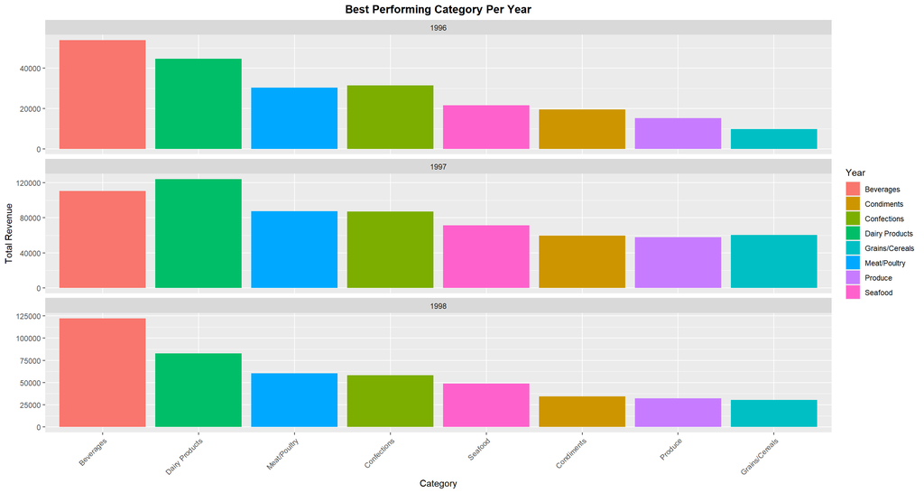

### Seasonal Trend By Product Per Year

| year | product_name | total_revenue |
| --- | --- | --- |
| 1996 | Côte de Blaye | 29512.00 |
| 1996 | Thüringer Rostbratwurst | 12177.00 |
| 1996 | Raclette Courdavault | 10164.00 |
| 1996 | Camembert Pierrot | 10064.00 |
| 1996 | Tarte au sucre | 9850.00 |
| 1997 | Côte de Blaye | 51962.20 |
| 1997 | Raclette Courdavault | 37917.00 |
| 1997 | Thüringer Rostbratwurst | 36194.18 |
| 1997 | Gnocchi di nonna Alice | 34754.80 |
| 1997 | Manjimup Dried Apples | 26065.40 |
| 1998 | Côte de Blaye | 68510.00 |
| 1998 | Thüringer Rostbratwurst | 39365.22 |
| 1998 | Raclette Courdavault | 28215.00 |
| 1998 | Camembert Pierrot | 18428.00 |
| 1998 | Tarte au sucre | 17304.30 |

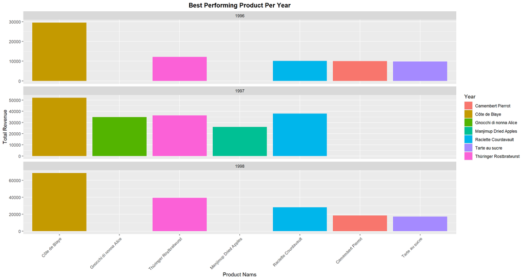

## 6 Optimizing Customer Value: Analyzing Northwind’s Average Order Size Dynamics

**The Challenge:** Beyond merely tracking total revenue, understanding the average order size is critical for grasping customer purchasing behavior. A higher average order size can indicate successful cross-selling, upselling, or bulk purchasing, contributing to greater efficiency and profitability. For Northwind Traders, monitoring this metric over time allows for a deeper evaluation of sales strategies and customer value.

**Our Approach:** To investigate the dynamics of order size, our analysis focused on:

1. **Annual Average Order Size:** Calculating the mean `order_quantity` for each year to observe overall trends in order magnitude.
2. **Monthly Average Order Size:** Examining the mean `order_quantity` per month across all years to identify any consistent seasonal fluctuations in order size.
3. **Distribution of Order Sizes:** Utilizing box plots to visualize the distribution of `order_quantity` values for each year, providing insights into the typical range and variability of orders, including the presence of outliers.

**Key Findings & Insights:**

### 6.1 Average Order Size: A Consistent Customer Behavior

Our analysis reveals a remarkably consistent average order size across the years for which data is available.

The average order quantity hovers around **23-24 units** across all three years. Specifically, it was **23.66 units in 1996, 24.07 units in 1997, and 23.51 units in 1998.**

The box plots below further illustrate this consistency in the central tendency of order sizes year over year, with the red line indicating the mean. While there are outliers representing larger orders, the bulk of transactions fall within a relatively stable range.

- **Strategic Implication:** This consistency suggests that Northwind’s core customer base exhibits a stable purchasing behavior in terms of quantity. This predictability can be beneficial for inventory forecasting and understanding baseline demand. It also implies that current sales strategies (pricing, product bundles, etc.) are yielding a relatively uniform order size.

### 6.2 Monthly Fluctuations in Order Size: Subtle Seasonal Hints

While the annual average order size remains stable, a deeper dive into monthly averages across all years reveals some subtle variations.

The monthly breakdown within each year further supports observing these nuanced patterns:

**Conclusion & Next Steps:**

Building upon these insights, future analysis could explore:

- **Correlation with Promotions:** Examining if specific promotions or sales events correlate with increases in average order size.
- **Customer Segmentation by Order Size:** Identifying distinct customer segments based on their typical order quantities (e.g., small, medium, bulk buyers).
- **Product Bundling Effectiveness:** Assessing if product bundles or “buy more, save more” initiatives could further increase average order value.
- **Outlier Analysis:** A deeper look into the large outlier orders identified in the box plots to understand their characteristics and potential for replication.

By understanding the dynamics of average order size, Northwind can refine its sales strategies to not only attract more orders but also encourage customers to purchase greater quantities, thereby maximizing customer value and revenue efficiency.

### 6.3 Average Order Size By Year

| year | mean |
| --- | --- |
| 1996 | 23.66 |
| 1997 | 24.07 |
| 1998 | 23.51 |

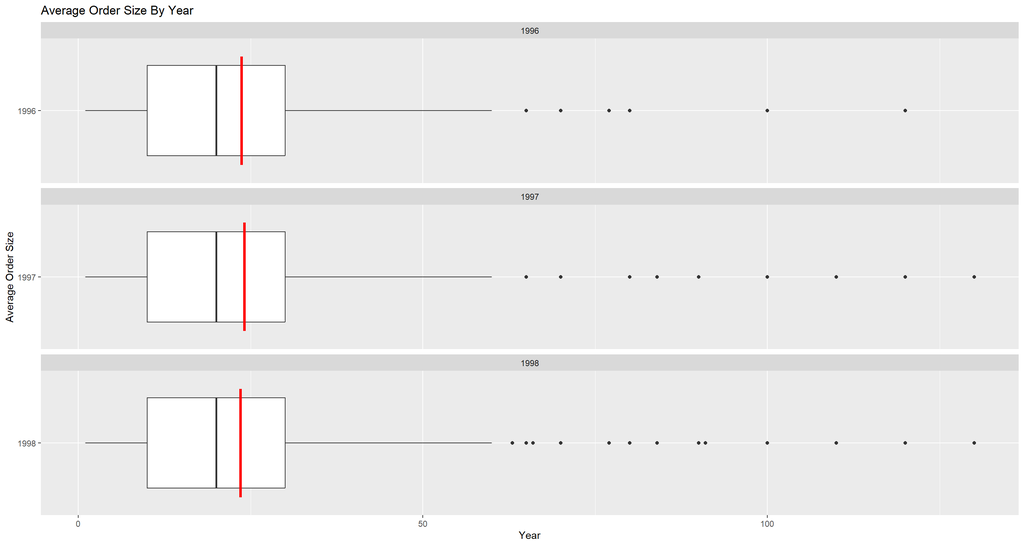

[output not shown]

| year | month | avg |
| --- | --- | --- |
| 1996 | December | 27.16 |
| 1996 | November | 26.29 |
| 1996 | July | 24.78 |
| 1996 | October | 23.81 |
| 1996 | September | 19.72 |
| 1996 | August | 19.16 |
| 1997 | January | 28.25 |
| 1997 | February | 26.99 |
| 1997 | July | 26.68 |
| 1997 | October | 25.27 |
| 1997 | September | 24.66 |
| 1997 | April | 23.60 |
| 1997 | December | 23.53 |
| 1997 | March | 22.99 |
| 1997 | May | 22.54 |
| 1997 | August | 22.15 |
| 1997 | June | 21.51 |
| 1997 | November | 20.85 |
| 1998 | April | 26.00 |
| 1998 | February | 25.53 |
| 1998 | March | 22.84 |
| 1998 | January | 22.80 |
| 1998 | May | 15.61 |

[figure not shown]

## 7 Conclusion and Business Recommendations for Northwind Traders

### 7.1 Conclusion: A Data-Driven Understanding of Northwind’s Sales Landscape

Our comprehensive Exploratory Data Analysis (EDA) of the Northwind database has provided critical insights into the company’s sales performance, revealing both its foundational strengths and dynamic temporal patterns.

We’ve established that **Beverages, Dairy Products, and Meat/Poultry** are the undisputed revenue powerhouses, with specific items like **Côte de Blaye** standing out as exceptional individual contributors. This highlights a concentrated reliance on a few key segments and products for the majority of Northwind’s revenue.

In essence, Northwind’s sales are characterized by a strong core of high-value products and categories, underpinned by predictable annual and seasonal demand patterns, with customers consistently ordering a similar volume of goods.

### 7.2 Business Recommendations: Actionable Strategies for Growth and Optimization

Based on these findings, we propose the following actionable business recommendations for Northwind Traders:

#### 7.2.1 1. Strategic Product & Inventory Management:

- **Prioritize Core Categories:** Maintain robust stock levels and focus quality control on **Beverages, Dairy Products, and Meat/Poultry**. These are your primary revenue drivers and any disruption could significantly impact the top line.
- **“Cash Cow” Focus:** Closely monitor and ensure consistent availability of top individual products like **Côte de Blaye**. Consider premium placement or dedicated marketing for these high-value items.
- **Supplier Relationship Management:** Strengthen relationships with suppliers for top-performing products and categories to ensure supply chain resilience, especially during peak seasons.
- **Cross-Selling Opportunities:** Analyze purchasing patterns within top categories. For instance, if customers buy “Beverages,” what “Dairy Products” or “Confections” are they also likely to purchase? Develop targeted cross-selling initiatives or product bundles.

#### 7.2.4 4. Recommendations for Further Analysis:

- **Profitability Analysis:** Extend the current revenue-based analysis to include cost data, allowing for the calculation of gross and net profit margins by product and category. This will reveal true profitability drivers.
- **Customer Lifetime Value (CLTV):** Segment customers and analyze their purchasing frequency and value over time to identify high-value customers and tailor retention strategies.
- **Geographical Performance:** If location data is available, analyze sales trends and top performers by region to identify market-specific opportunities or challenges.
- **Impact of Promotions:** If historical promotion data exists, analyze its correlation with sales volume and average order size to determine the effectiveness of past marketing efforts.
- **1998 Data Completion:** Obtain the complete 1998 sales data to gain a full understanding of the annual trend and accurately assess year-over-year growth or decline.

By strategically implementing these recommendations, Northwind Traders can leverage its existing sales strengths, proactively manage seasonal demand, and optimize its operations for sustained growth and profitability.